# HW2_Gupta362

Abhisek

September 10, 2016

## Answer 1

The business problem in question is: Credit card companies are dealing with a lot of customers who are defaulting on their payments. This is happening because the initial customer targeting didnt include reigorous canvassing of a customer’s ability to repay in time. The final statement in this case would be “Assesing the credit risk(Probability of delay in credit card payment) of the prospective credit cardholder.”

## Question 2

Read the short paper “The comparisons of data mining techniques for the predictive accuracy of probability of default of credit card clients” by Lei and Chen and identify how they formulated the business problem into an analytics problem (or at least attempted to). This means, how they are using quantitative methods to help provide support for the business problem.

## Answer 2

Credit card companies will hugely benefit if they are able to identify which customer is more likely to pay on time and which is not. If transaction data, financial stement and payments records are available to the company, they can use this data to build a model which will predict future customer behavior. Predictive analytics in this case can be used to either give individual probabilities or the binary response(At risk/Not at risk) for each customer. This will help the credit card companies to give cards only to less risky customers who are less likely to default on their payments.

## Question 3

Create a data dictionary table of the variables in the data set. The dictionary names should match exactly the names you loaded into R.

```r
library(knitr)
ID = "ID: observation ID"
Y = "Y: default payment (Yes = 1, No = 0), as the response variable"
X1_LIMIT_BAL = "X1_LIMIT_BAL: Amount of the given credit (NT dollar): it includes both the individual consumer credit and his/her family (supplementary) credit."
X2_SEX = "X2_SEX: (1 = Male, 2 = Female)"
X3_EDUCATION = "X3_EDUCATION: (1 = graduate school; 2 = university; 3 = high school; 4 = others)"
X4_MARRIAGE = "X4_MARRIAGE: (1 = married; 2 = single; 3 = others)"
X5_AGE = "X5_AGE: Age (Years)"
X6_PAY_0 ="X6_PAY_0: the repayment status in September, 2005 where 0 = No Delay, -1 = pay duly, 1 = payment delay for one month"
X7_PAY_2 ="X6_PAY_2: the repayment status in August, 2005 where 0 = No Delay, -1 = pay duly, 1 = payment delay for one month"
X8_PAY_3 ="X6_PAY_3: the repayment status in July, 2005 where 0 = No Delay, -1 = pay duly, 1 = payment delay for one month"
X9_PAY_4 ="X6_PAY_4: the repayment status in June, 2005 where 0 = No Delay, -1 = pay duly, 1 = payment delay for one month"
X10_PAY_5 ="X6_PAY_5: the repayment status in May, 2005 where 0 = No Delay, -1 = pay duly, 1 = payment delay for one month"
X11_PAY_6 ="X6_PAY_6: the repayment status in April, 2005 where 0 = No Delay, -1 = pay duly, 1 = payment delay for one month"
X12_BILL_AMT1 = "X12_BILL_AMT1: amount of bill statement (NT Dollar) in September, 2005"
X13_BILL_AMT2 = "X12_BILL_AMT2: amount of bill statement (NT Dollar) in August, 2005"
X14_BILL_AMT3 = "X12_BILL_AMT3: amount of bill statement (NT Dollar) in July, 2005"
X15_BILL_AMT4 = "X12_BILL_AMT4: amount of bill statement (NT Dollar) in June, 2005"
X16_BILL_AMT5 = "X12_BILL_AMT5: amount of bill statement (NT Dollar) in May, 2005"
X17_BILL_AMT6 = "X12_BILL_AMT6: amount of bill statement (NT Dollar) in April, 2005"
X18_PAY_AMT1 = "X12_BILL_AMT1: amount of bill previous bill paid (NT Dollar) in September, 2005"
X19_PAY_AMT2 = "X12_BILL_AMT2: amount of bill previous bill paid (NT Dollar) in August, 2005"
X20_PAY_AMT3 = "X12_BILL_AMT3: amount of bill previous bill paid (NT Dollar) in July, 2005"
X21_PAY_AMT4 = "X12_BILL_AMT4: amount of bill previous bill paid (NT Dollar) in June, 2005"
X22_PAY_AMT5 = "X12_BILL_AMT5: amount of bill previous bill paid (NT Dollar) in May, 2005"
X23_PAY_AMT6 = "X12_BILL_AMT6: amount of bill previous bill paid (NT Dollar) in April, 2005"

variables <- c(ID,Y,X1_LIMIT_BAL,X2_SEX,X3_EDUCATION, X4_MARRIAGE, X5_AGE, X6_PAY_0, X7_PAY_2, X8_PAY_3,X9_PAY_4,X10_PAY_5, X11_PAY_6, X12_BILL_AMT1, X13_BILL_AMT2, X14_BILL_AMT3, X15_BILL_AMT4, X16_BILL_AMT5, X17_BILL_AMT6, X18_PAY_AMT1, X19_PAY_AMT2, X20_PAY_AMT3,X21_PAY_AMT4,X22_PAY_AMT5, X23_PAY_AMT6)
kable(variables, caption = "Dataset description", col.names = "Column Name", padding = 5)
```

Dataset description

| Column Name |
| --- |
| ID: observation ID |
| Y: default payment (Yes = 1, No = 0), as the response variable |
| X1_LIMIT_BAL: Amount of the given credit (NT dollar): it includes both the individual consumer credit and his/her family (supplementary) credit. |
| X2_SEX: (1 = Male, 2 = Female) |
| X3_EDUCATION: (1 = graduate school; 2 = university; 3 = high school; 4 = others) |
| X4_MARRIAGE: (1 = married; 2 = single; 3 = others) |
| X5_AGE: Age (Years) |
| X6_PAY_0: the repayment status in September, 2005 where 0 = No Delay, -1 = pay duly, 1 = payment delay for one month |
| X6_PAY_2: the repayment status in August, 2005 where 0 = No Delay, -1 = pay duly, 1 = payment delay for one month |
| X6_PAY_3: the repayment status in July, 2005 where 0 = No Delay, -1 = pay duly, 1 = payment delay for one month |
| X6_PAY_4: the repayment status in June, 2005 where 0 = No Delay, -1 = pay duly, 1 = payment delay for one month |
| X6_PAY_5: the repayment status in May, 2005 where 0 = No Delay, -1 = pay duly, 1 = payment delay for one month |
| X6_PAY_6: the repayment status in April, 2005 where 0 = No Delay, -1 = pay duly, 1 = payment delay for one month |
| X12_BILL_AMT1: amount of bill statement (NT Dollar) in September, 2005 |
| X12_BILL_AMT2: amount of bill statement (NT Dollar) in August, 2005 |
| X12_BILL_AMT3: amount of bill statement (NT Dollar) in July, 2005 |
| X12_BILL_AMT4: amount of bill statement (NT Dollar) in June, 2005 |
| X12_BILL_AMT5: amount of bill statement (NT Dollar) in May, 2005 |
| X12_BILL_AMT6: amount of bill statement (NT Dollar) in April, 2005 |
| X12_BILL_AMT1: amount of bill previous bill paid (NT Dollar) in September, 2005 |
| X12_BILL_AMT2: amount of bill previous bill paid (NT Dollar) in August, 2005 |
| X12_BILL_AMT3: amount of bill previous bill paid (NT Dollar) in July, 2005 |
| X12_BILL_AMT4: amount of bill previous bill paid (NT Dollar) in June, 2005 |
| X12_BILL_AMT5: amount of bill previous bill paid (NT Dollar) in May, 2005 |
| X12_BILL_AMT6: amount of bill previous bill paid (NT Dollar) in April, 2005 |

## Question 4:

Set Y, X2_SEX, and X4_MARRIAGE as unordered factors. After you do this, prove with an R function that they are indeed factors.

```r
credit_data <- read.csv(file="creditCardDefaultData.csv", head = TRUE, sep=",")
head(credit_data)
```

```
##   ID Y X1_LIMIT_BAL X2_SEX X3_EDUCATION X4_MARRIAGE X5_AGE X6_PAY_0
## 1  1 1        20000      2            2           1     24        2
## 2  2 1       120000      2            2           2     26       -1
## 3  3 0        90000      2            2           2     34        0
## 4  4 0        50000      2            2           1     37        0
## 5  5 0        50000      1            2           1     57       -1
## 6  6 0        50000      1            1           2     37        0
##   X7_PAY_2 X8_PAY_3 X9_PAY_4 X10_PAY_5 X11_PAY_6 X12_BILL_AMT1
## 1        2       -1       -1        -2        -2          3913
## 2        2        0        0         0         2          2682
## 3        0        0        0         0         0         29239
## 4        0        0        0         0         0         46990
## 5        0       -1        0         0         0          8617
## 6        0        0        0         0         0         64400
##   X13_BILL_AMT2 X14_BILL_AMT3 X15_BILL_AMT4 X16_BILL_AMT5 X17_BILL_AMT6
```

[output cut: 20 more lines]

```r
credit_data$Y <- factor(credit_data$Y, labels = c("Not_default","Default"), ordered = FALSE)
class(credit_data$Y)
```

```
## [1] "factor"
```

```r
credit_data$X2_SEX <- factor(credit_data$X2_SEX, labels = c("Male","Female"), ordered = FALSE)
class(credit_data$X2_SEX)
```

```
## [1] "factor"
```

```r
credit_data$X4_MARRIAGE <- factor(credit_data$X4_MARRIAGE, ordered = FALSE)
class(credit_data$X4_MARRIAGE)
```

```
## [1] "factor"
```

```r
str(credit_data)
```

```
## 'data.frame':    30000 obs. of  25 variables:
##  $ ID           : int  1 2 3 4 5 6 7 8 9 10 ...
##  $ Y            : Factor w/ 2 levels "Not_default",..: 2 2 1 1 1 1 1 1 1 1 ...
##  $ X1_LIMIT_BAL : int  20000 120000 90000 50000 50000 50000 500000 100000 140000 20000 ...
##  $ X2_SEX       : Factor w/ 2 levels "Male","Female": 2 2 2 2 1 1 1 2 2 1 ...
##  $ X3_EDUCATION : int  2 2 2 2 2 1 1 2 3 3 ...
##  $ X4_MARRIAGE  : Factor w/ 4 levels "0","1","2","3": 2 3 3 2 2 3 3 3 2 3 ...
##  $ X5_AGE       : int  24 26 34 37 57 37 29 23 28 35 ...
##  $ X6_PAY_0     : int  2 -1 0 0 -1 0 0 0 0 -2 ...
##  $ X7_PAY_2     : int  2 2 0 0 0 0 0 -1 0 -2 ...
##  $ X8_PAY_3     : int  -1 0 0 0 -1 0 0 -1 2 -2 ...
##  $ X9_PAY_4     : int  -1 0 0 0 0 0 0 0 0 -2 ...
##  $ X10_PAY_5    : int  -2 0 0 0 0 0 0 0 0 -1 ...
##  $ X11_PAY_6    : int  -2 2 0 0 0 0 0 -1 0 -1 ...
##  $ X12_BILL_AMT1: int  3913 2682 29239 46990 8617 64400 367965 11876 11285 0 ...
##  $ X13_BILL_AMT2: int  3102 1725 14027 48233 5670 57069 412023 380 14096 0 ...
##  $ X14_BILL_AMT3: int  689 2682 13559 49291 35835 57608 445007 601 12108 0 ...
##  $ X15_BILL_AMT4: int  0 3272 14331 28314 20940 19394 542653 221 12211 0 ...
##  $ X16_BILL_AMT5: int  0 3455 14948 28959 19146 19619 483003 -159 11793 13007 ...
##  $ X17_BILL_AMT6: int  0 3261 15549 29547 19131 20024 473944 567 3719 13912 ...
##  $ X18_PAY_AMT1 : int  0 0 1518 2000 2000 2500 55000 380 3329 0 ...
##  $ X19_PAY_AMT2 : int  689 1000 1500 2019 36681 1815 40000 601 0 0 ...
##  $ X20_PAY_AMT3 : int  0 1000 1000 1200 10000 657 38000 0 432 0 ...
##  $ X21_PAY_AMT4 : int  0 1000 1000 1100 9000 1000 20239 581 1000 13007 ...
##  $ X22_PAY_AMT5 : int  0 0 1000 1069 689 1000 13750 1687 1000 1122 ...
##  $ X23_PAY_AMT6 : int  0 2000 5000 1000 679 800 13770 1542 1000 0 ...
```

## Problem 5

Set any numbers for X3_EDUCATION that are not 1,2,3, or 4 to 4. Then, change X3_EDUCATION to an ordered factor where 4 < 3 < 2 < 1. –>

```r
credit_data$X3_EDUCATION[credit_data$X3_EDUCATION != c(1,2,3,4)] <- 4

credit_data$X3_EDUCATION <- factor(credit_data$X3_EDUCATION, ordered = TRUE)

credit_data$X3_EDUCATION <- factor(credit_data$X3_EDUCATION, levels=rev(levels(credit_data$X3_EDUCATION)))

str(credit_data)
```

```
## 'data.frame':    30000 obs. of  25 variables:
##  $ ID           : int  1 2 3 4 5 6 7 8 9 10 ...
##  $ Y            : Factor w/ 2 levels "Not_default",..: 2 2 1 1 1 1 1 1 1 1 ...
##  $ X1_LIMIT_BAL : int  20000 120000 90000 50000 50000 50000 500000 100000 140000 20000 ...
##  $ X2_SEX       : Factor w/ 2 levels "Male","Female": 2 2 2 2 1 1 1 2 2 1 ...
##  $ X3_EDUCATION : Ord.factor w/ 4 levels "4"<"3"<"2"<"1": 1 3 1 1 1 1 1 1 1 1 ...
##  $ X4_MARRIAGE  : Factor w/ 4 levels "0","1","2","3": 2 3 3 2 2 3 3 3 2 3 ...
##  $ X5_AGE       : int  24 26 34 37 57 37 29 23 28 35 ...
##  $ X6_PAY_0     : int  2 -1 0 0 -1 0 0 0 0 -2 ...
##  $ X7_PAY_2     : int  2 2 0 0 0 0 0 -1 0 -2 ...
##  $ X8_PAY_3     : int  -1 0 0 0 -1 0 0 -1 2 -2 ...
##  $ X9_PAY_4     : int  -1 0 0 0 0 0 0 0 0 -2 ...
##  $ X10_PAY_5    : int  -2 0 0 0 0 0 0 0 0 -1 ...
##  $ X11_PAY_6    : int  -2 2 0 0 0 0 0 -1 0 -1 ...
##  $ X12_BILL_AMT1: int  3913 2682 29239 46990 8617 64400 367965 11876 11285 0 ...
##  $ X13_BILL_AMT2: int  3102 1725 14027 48233 5670 57069 412023 380 14096 0 ...
##  $ X14_BILL_AMT3: int  689 2682 13559 49291 35835 57608 445007 601 12108 0 ...
##  $ X15_BILL_AMT4: int  0 3272 14331 28314 20940 19394 542653 221 12211 0 ...
##  $ X16_BILL_AMT5: int  0 3455 14948 28959 19146 19619 483003 -159 11793 13007 ...
##  $ X17_BILL_AMT6: int  0 3261 15549 29547 19131 20024 473944 567 3719 13912 ...
##  $ X18_PAY_AMT1 : int  0 0 1518 2000 2000 2500 55000 380 3329 0 ...
##  $ X19_PAY_AMT2 : int  689 1000 1500 2019 36681 1815 40000 601 0 0 ...
##  $ X20_PAY_AMT3 : int  0 1000 1000 1200 10000 657 38000 0 432 0 ...
##  $ X21_PAY_AMT4 : int  0 1000 1000 1100 9000 1000 20239 581 1000 13007 ...
##  $ X22_PAY_AMT5 : int  0 0 1000 1069 689 1000 13750 1687 1000 1122 ...
##  $ X23_PAY_AMT6 : int  0 2000 5000 1000 679 800 13770 1542 1000 0 ...
```

## Problem 6

Source the two data quality functions (i.e. DataQualityReport.R and DataQualityReportOverall.R) and report the results. If there are any incomplete records you have done something incorrectly in problems 4 or 5. Y, X2_SEX, X4_MARRIAGE, and X3_EDUCATION should show up as factors while the other variables as numeric

```r
source("DataQualityReport.R")
source("DataQualityReportOverall.R")

DataQualityReport(credit_data)
```

```
##       Attributes    Type NumberMissing PercentComplete     Min       Avg
## 1             ID numeric             0             100       1   15000.5
## 2              Y  factor             0             100       -         -
## 3   X1_LIMIT_BAL numeric             0             100   10000 167484.32
## 4         X2_SEX  factor             0             100       -         -
## 5   X3_EDUCATION  factor             0             100       -         -
## 6    X4_MARRIAGE  factor             0             100       -         -
## 7         X5_AGE numeric             0             100      21     35.49
## 8       X6_PAY_0 numeric             0             100      -2     -0.02
## 9       X7_PAY_2 numeric             0             100      -2     -0.13
## 10      X8_PAY_3 numeric             0             100      -2     -0.17
## 11      X9_PAY_4 numeric             0             100      -2     -0.22
## 12     X10_PAY_5 numeric             0             100      -2     -0.27
## 13     X11_PAY_6 numeric             0             100      -2     -0.29
## 14 X12_BILL_AMT1 numeric             0             100 -165580  51223.33
```

[output cut: 37 more lines]

```r
DataQualityReportOverall(credit_data)
```

```
##   CompleteCases IncompleteCases CompleteCasePct
## 1         30000               0             100
```

## Problem 7

Using R code, find the age of the person who’s X12_BILL_AMT1 is equal to 964511. What is their age?

```r
age <- credit_data$X5_AGE[credit_data$X12_BILL_AMT1 == 964511]
age
```

```
## [1] 47
```

## Problem 8

Using R code, find the number of males that have graduate education. –>

```r
count <- nrow(subset(credit_data, credit_data$X3_EDUCATION == '1'))
count
```

```
## [1] 2653
```

## Problem 9

Using R code, find the proportion of people that are below average in age among those that have defaulted (i.e. Y==1).

```r
mean_age <- mean(credit_data$X5_AGE)
count_ma_def <- nrow(subset(credit_data , credit_data$X5_AGE < mean_age & credit_data$Y == "Default"))
count_tot <- nrow(subset(credit_data , credit_data$Y == "Default"))

Perc <- (count_ma_def/count_tot)*100
Perc
```

```
## [1] 54.20434
```

## Problem 10

Use the ggplot2 package to plot a boxplot of X1_LIMIT_BAL by Y. Should look similar to below. Does the plot suggest there is a statistically significant difference among the two groups?

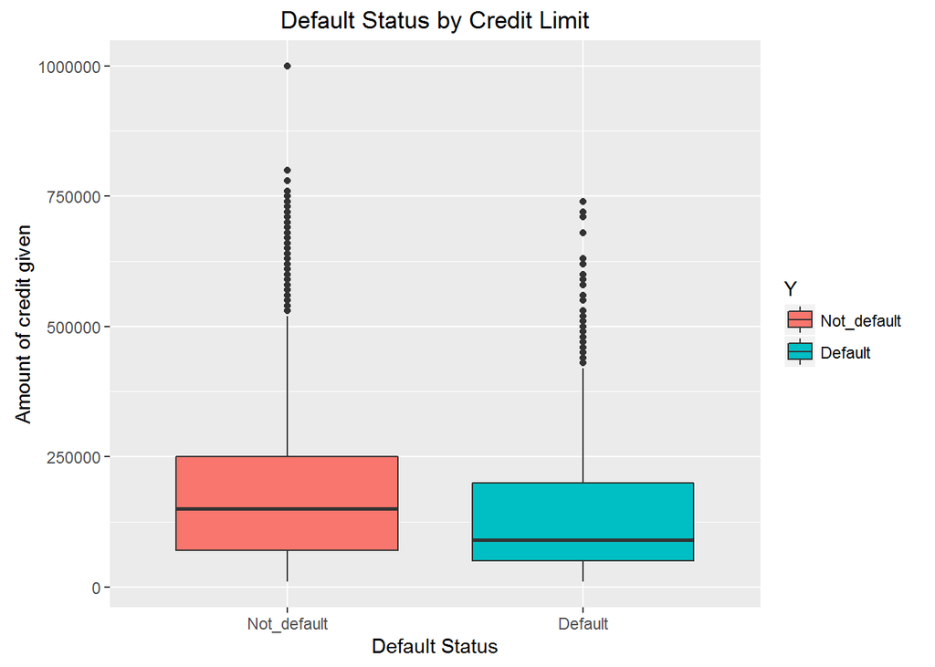

```r
library(ggplot2)
qplot(credit_data$Y, credit_data$X1_LIMIT_BAL, data=credit_data, geom=c("boxplot"), fill=Y, main="Default Status by Credit Limit", ylab="Amount of credit given", xlab="Default Status")
```

The median amount of credit given to cardholders defaulting is less than the median amount of credit of cardholders not defaulting on the payment.

## Problem 11

Source the multiplot.R function so you can create multiple qplots in the same window. You can see examples of how to use this function in the following link. Have the first figure show the distribution of credit card balance by default group in NT (New Taiwan) dollars, and another distribution plot of the credit balance by default group in US dollars. Note: To answer this question, you’ll need to figure out what the currency adjustment is. –>

```r
#Adding a column in USD
source("multiplot.R")

credit_data[["X1_LIMIT_BAL_USD"]] <- (credit_data$X1_LIMIT_BAL)*0.032
head(credit_data$X1_LIMIT_BAL_USD)
```

```
## [1]  640 3840 2880 1600 1600 1600
```

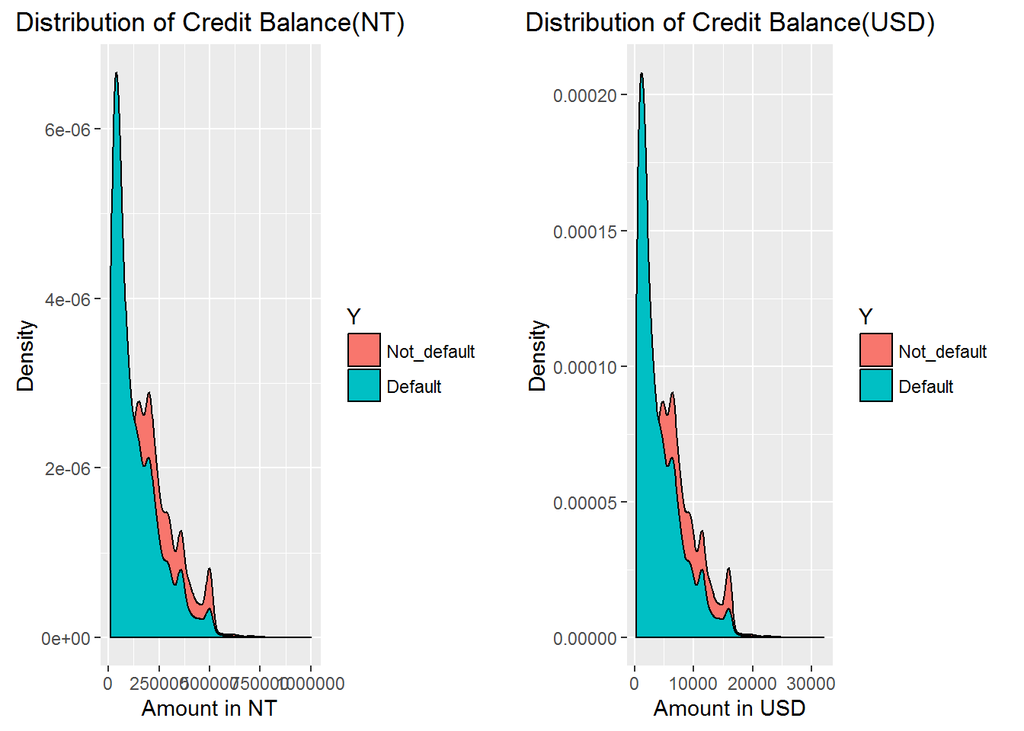

```r
nt_plot <- qplot(x=X1_LIMIT_BAL,data = credit_data, main = "Distribution of Credit Balance(NT)",geom = "density", xlab = "Amount in NT", ylab = "Density", fill = Y)

usd_plot <- qplot(x=X1_LIMIT_BAL_USD, data = credit_data, main = "Distribution of Credit Balance(USD)",geom = "density", xlab = "Amount in USD", ylab = "Density", fill = Y)

multiplot(nt_plot, usd_plot, cols = 2)
```